# Time-varying risk factor exploration

Andrew Mertens

March 14, 2018

### Studies with percent days with Diarrhea

(Percent of total days under observation that the child had diarrhea during. Not time-varying-for the whole study duration.)

```
##
##  ki1000108-CMC-V-BCS-2002             ki1000108-IRC
##                     15230                     13901
##             ki1000108-TDC              ki1000109-EE
##                      3392                      8448
##          ki1000109-ResPak       ki1017093-NIH-Birth
##                      3287                     11721
## ki1112895-Burkina Faso Zn   ki1112895-Guatemala BSC
##                     18969                      2544
##      ki1112895-iLiNS-Zinc    ki1112895-Peru Huascar
##                      9987                      1839
##            ki1114097-CMIN         ki1114097-CONTENT
##                    141744                      8116
##        ki1126311-ZVITAMBO         kiGH5241-JiVitA-4
##                     64422                     39529
```

### Stratified by diarrhea flag variable

```
##
##                                  0      1
##   ki1000108-CMC-V-BCS-2002       0      0
##   ki1000108-IRC                  0      0
##   ki1000108-TDC                  0      0
##   ki1000109-EE                7916    530
##   ki1000109-ResPak            2729    454
##   ki1017093-NIH-Birth         7804   3267
##   ki1112895-Burkina Faso Zn     58     76
##   ki1112895-Guatemala BSC      169    248
##   ki1112895-iLiNS-Zinc        5777    151
##   ki1112895-Peru Huascar       188    394
##   ki1114097-CMIN            114376   9888
##   ki1114097-CONTENT           7883    233
##   ki1126311-ZVITAMBO         50010   1032
##   kiGH5241-JiVitA-4              0      0
```

### Drop diarrhea and breastfeeding variables variables that are actually subject level, rather than time-varying

```r
d <- subset(d, select= -c(DIARDAYS, DIAREPS, DURBRST, PCTDIAR, SUMEP,SUMDIAR, SUMDAYS))
```

### Bar plot of SD’s of each time varying variable

Variables: * COUGHFL: Flag for child has cough at time of observation * DIARFL: Flag for child has diarrhea at time of observation * BFEDFL: Flag for child has breastfed on the day of observation

Barplot shows the mean of within-child standard deviations of time-varying indicators. Mean SD’s of 0 indicated that the variable has no within-child variation within that study. Mean SD’s of 0 have been recoded to -0.1 for visability, so variables with no bars indicate the variable is not present in a study.

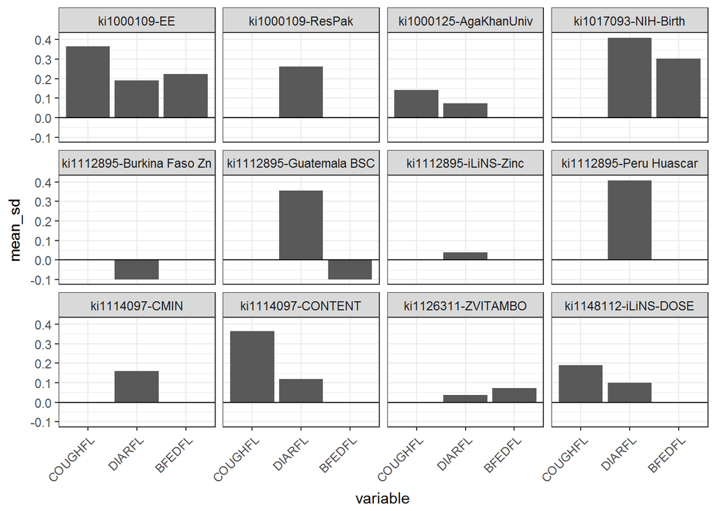

## Mortality plots

### Compare DEAD flag across studies

```
##
##                                 0     1
##   ki1000108-CMC-V-BCS-2002      0     0
##   ki1000108-IRC                 0     0
##   ki1000108-TDC                 0     0
##   ki1000109-EE                  0     0
##   ki1000109-ResPak              0     0
##   ki1000110-WASH-Bangladesh     0     0
##   ki1000111-WASH-Kenya          0     0
##   ki1000125-AgaKhanUniv         0     0
##   ki1000304-EU                  0     0
##   ki1000304-ZnMort              0     0
##   ki1000304b-SAS-CompFeed       0     0
##   ki1000304b-SAS-FoodSuppl      0     0
##   ki1017093-NIH-Birth           0     0
##   ki1017093c-NIH-Crypto         0     0
##   ki1066203-TanzaniaChild2      0     0
##   ki1101329-Keneba              0  1036
##   ki1112895-Burkina Faso Zn     0     0
##   ki1112895-Guatemala BSC       0     0
##   ki1112895-iLiNS-Zinc          0     0
##   ki1112895-Peru Huascar        0     0
##   ki1113344-GMS-Nepal       13427    21
##   ki1114097-CMIN                0     0
##   ki1114097-CONTENT             0     0
##   ki1119695-PROBIT              0     0
##   ki1126311-ZVITAMBO            0  2990
##   ki1135781-COHORTS             0     0
##   ki1148112-iLiNS-DOSE       8927   515
##   ki1148112-iLiNS-DYAD-M     5190    96
##   ki1148112-LCNI-5              0     0
##   kiGH5241-JiVitA-3             0     0
##   kiGH5241-JiVitA-4         39305   224
##   MAL-ED                        0     0
```

### Children marked dead who don’t have an age of death

Row: if age of death is missing Column: indicator if the child died

```
##
##             0     1
##   FALSE     0  4240
##   TRUE  66849   642
```

### Plot of ages of death of children across GHAP studies with mortality information

For each study with mortality, drop children who didn’t die. Rank order children by reported age of death. Y axis is rank. X axis is point and line of anthropometry observations (AGEDAYS) and X’s mark the recorded age of death. X is colored red if it occurs before the age of the child at the final observation of anthropometry (AKA the age at death is in error).

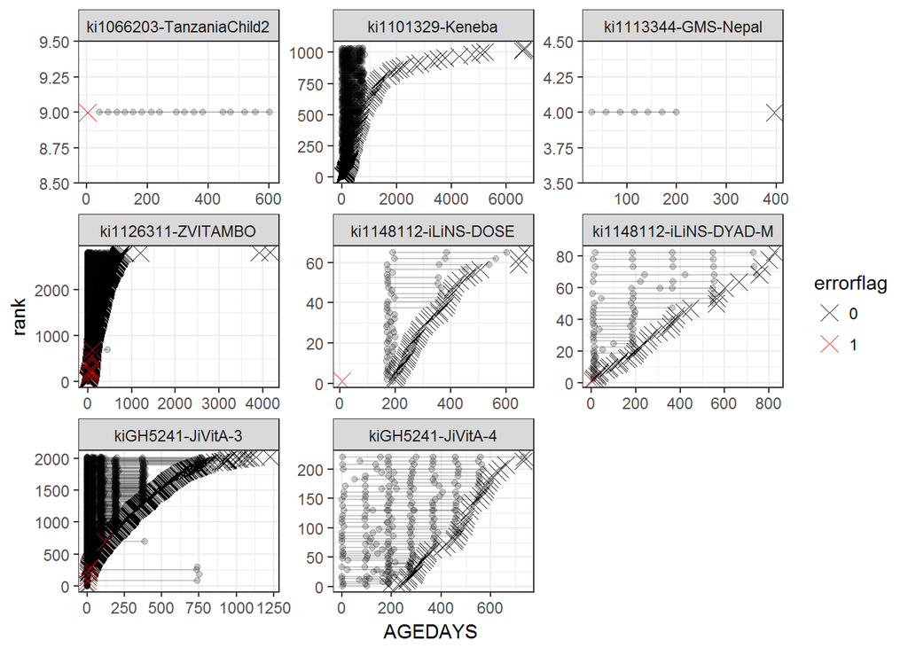